# Predicting the class of the Exercise

This report will provide the prediction model that was built for the $pml$ dataset, obtained from the source - “http://groupware.les.inf.puc-rio.br/har”. The report also provides the out of sample error calculated by bagging. The report is divided into the following sections:

- Data extraction
- Data analysis
- Prediction modeling
- Out of the sample error
- Response for the test data

**Data extraction:** The $pml-training$ and $pml-testing$ datasets are loaded into R. The datasets are then subsetted into smaller dataset by extracting only the variables (columns) that had non-blank values. This is done by using $grep$ function. The columns containing “name” and “time” are not considered for the subset.

```r
library(data.table)
library(randomForest)
```

```r
library(ggplot2)
library(lattice)
outofsample <-vector(length =10)
ml <- vector("list", length = 10)
trainDF <- read.csv("./pml-training.csv")
testDF <- read.csv("./pml-testing.csv")
trainDT1 <- data.table(trainDF)
testDF <- data.table(testDF)
nufn <- function(x) {
  grep(x, colnames(trainDT1), value = TRUE)

}
mufn <- function(x) {
  grep(x, colnames(testDF), value = TRUE)

}
lt <- c("^[g]yros_", "^[a]ccel_", "^[t]otal_","^[m]agnet_", "^[r]oll_", "^[p]itch_", "^[y]aw_","^[c]lasse")
mt <- c("^[g]yros_", "^[a]ccel_", "^[t]otal_","^[m]agnet_", "^[r]oll_", "^[p]itch_", "^[y]aw_")
valm <- unlist(lapply(lt, nufn))
trainpreds <- trainDT1[,valm, with = FALSE]
valn <- unlist(lapply(mt, mufn))
testpreds <- testDF[,valn, with = FALSE]
```

**Data analysis:** On analyzing the dataset, it can be inferred that the response variable is $categorical$ and the prediction problem is of $classification$ type. The predicted response belongs to the set $G = \{ A,B,C,D,E \}$

**Prediction modeling:** The method that is used to predict the class of the exercise is $random forest$. Since $random forest$ is based on $trees$, this method is chosen. Cross validation is performed within $random forest$ method by $bagging$.

```r
ml <- randomForest(x= trainpreds[,!"classe", with = FALSE], y = trainpreds$classe)
ml
```

```
##
## Call:
##  randomForest(x = trainpreds[, !"classe", with = FALSE], y = trainpreds$classe)
##                Type of random forest: classification
##                      Number of trees: 500
## No. of variables tried at each split: 7
##
##         OOB estimate of  error rate: 0.3%
## Confusion matrix:
##      A    B    C    D    E  class.error
## A 5578    2    0    0    0 0.0003584229
## B   12 3781    4    0    0 0.0042138530
## C    0   10 3409    3    0 0.0037989480
## D    0    0   19 3196    1 0.0062189055
## E    0    0    3    4 3600 0.0019406709
```

```r
outofsample <-(nrow(trainpreds) -sum(diag(ml$confusion)))/nrow(trainpreds)
classehat <- predict(ml,newdata=testpreds)
```

```r
outofsample
```

```
## [1] 0.002955866
```

**Response for the test data:** The response for the $pml-testing$ dataset predicted by the model is given below.

```r
classehat
```

```
##  1  2  3  4  5  6  7  8  9 10 11 12 13 14 15 16 17 18 19 20
##  B  A  B  A  A  E  D  B  A  A  B  C  B  A  E  E  A  B  B  B
## Levels: A B C D E
```

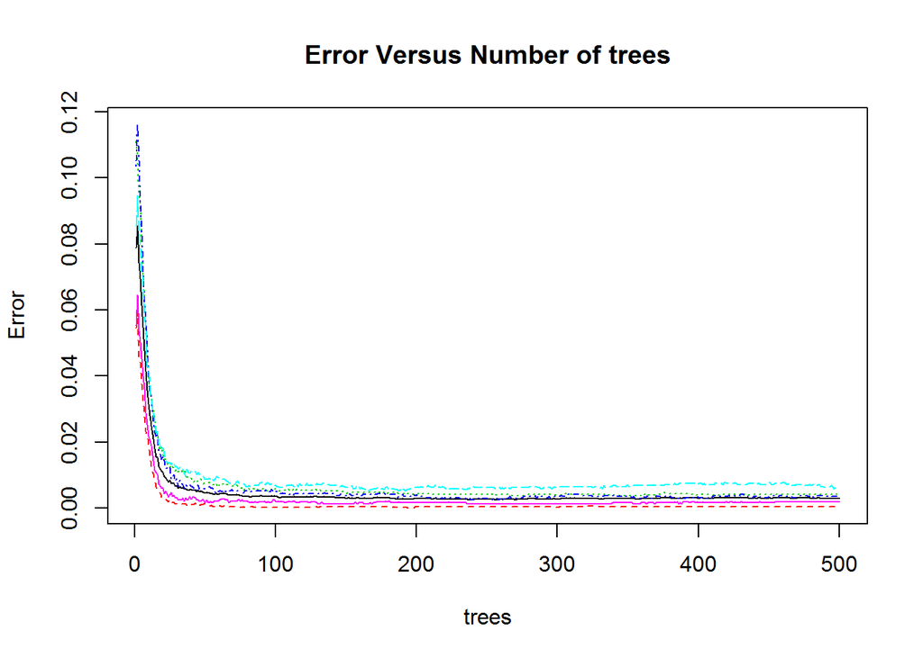

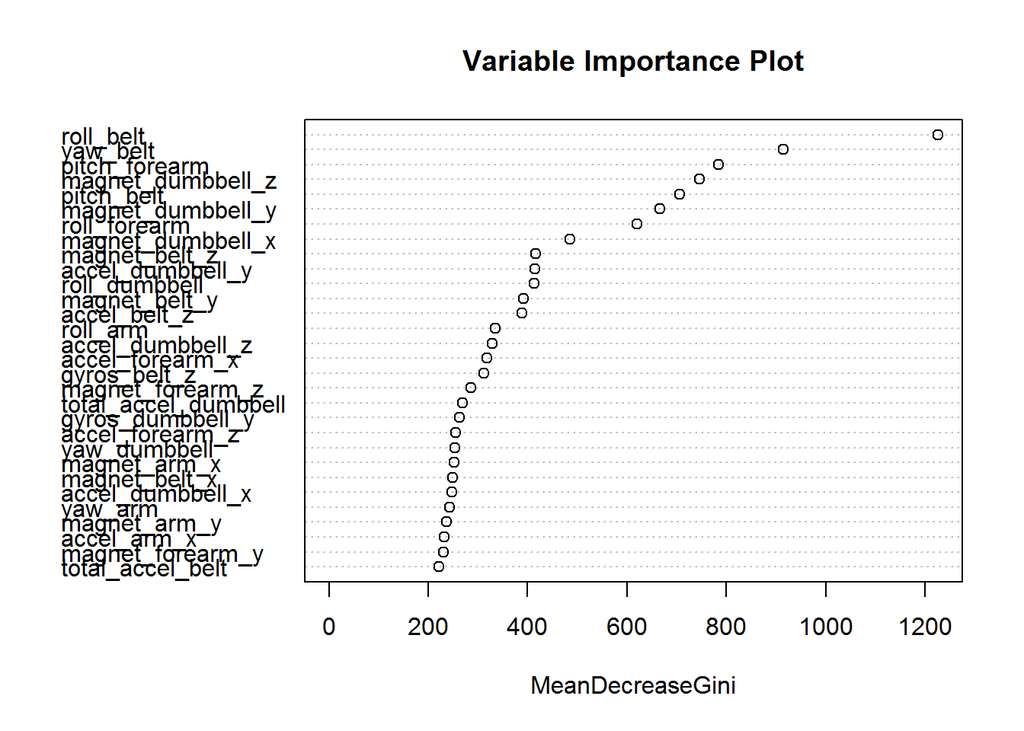